# Forecasting demographic variables

### 2.3.1 Modeling and forecasting popultion pyramids

```r
ppDemog.fit <- fdm(ppDemog, order=2)
ppDemog.fit
```

```
## Functional demographic model
##
## Call: fdm(data = ppDemog, order = 2)
##
## Region: Spain
## Data type: mortality
## Years in fit: 1950 - 2021
## Ages in fit: -100.5 - 100.5
##
## Order: 2
## Percentage variation due to basis functions: 75.9% 11.1%
```

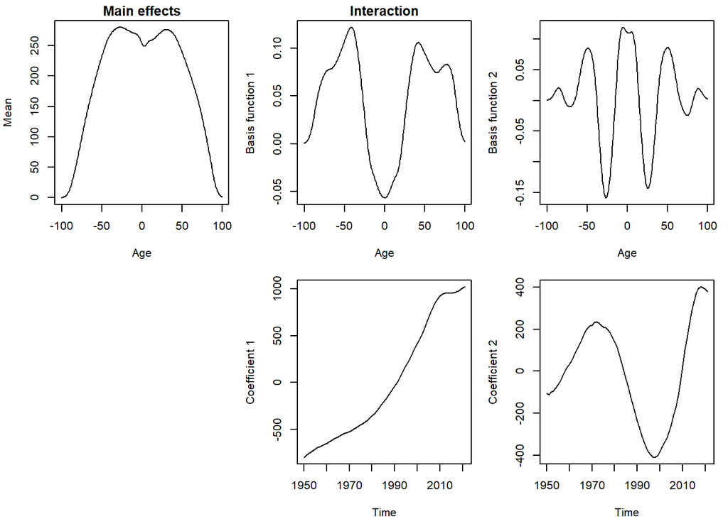

```r
par(mar=c(4,4,1.5,1))
plot(ppDemog.fit)
```

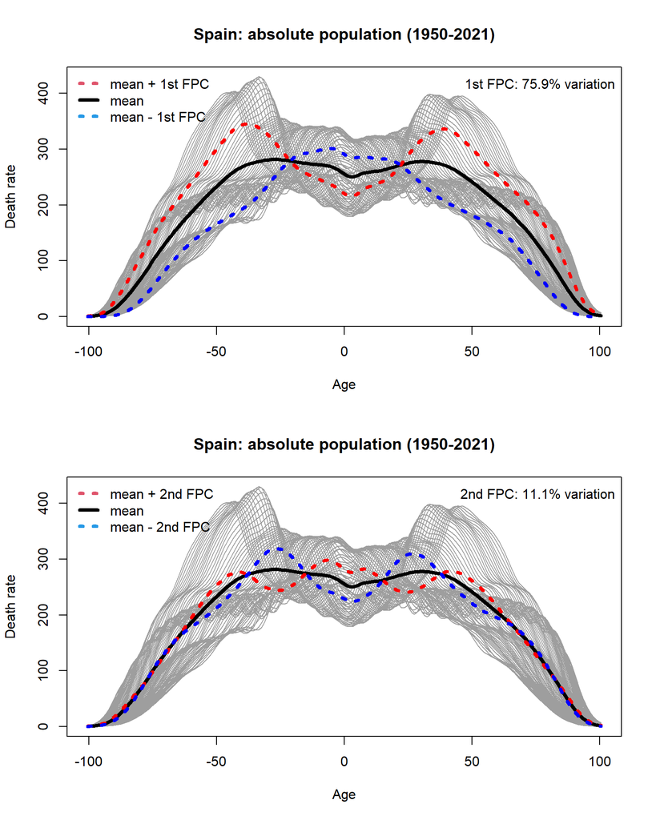

```r
par(mfrow=c(2,1))
plot(ppDemog,col=8,
     main=paste0(Country[ctr,1],": absolute population (",Year[1],"-", rev(Year)[1],")"))
lines(ppDemog$age, 1+ppDemog.fit$basis[,1],lwd=4)
eig_val_1 <- var(ppDemog.fit$coeff[,2])
lines(ppDemog$age, 1+ppDemog.fit$basis[,1]+sqrt(eig_val_1)*ppDemog.fit$basis[,2],lwd=4,col="red",lty=3)
lines(ppDemog$age, 1+ppDemog.fit$basis[,1]-sqrt(eig_val_1)*ppDemog.fit$basis[,2],lwd=4,col="blue",lty=3)
legend("topleft",c("mean + 1st FPC ", "mean", "mean - 1st FPC "),
       lty=c(3,1,3), col=c(2,1,4), lwd=4, bty="n",seg.len = 1.5)
legend("topright",paste0("1st FPC: ",round(100*ppDemog.fit$varprop[1],1),"% variation"), bty="n")


plot(ppDemog,col=8,
     main=paste0(Country[ctr,1],": absolute population (",Year[1],"-", rev(Year)[1],")"))
lines(ppDemog$age, 1+ppDemog.fit$basis[,1],lwd=4)
eig_val_2 <- var(ppDemog.fit$coeff[,3])
cte=1
lines(ppDemog$age, 1+ppDemog.fit$basis[,1]+cte*sqrt(eig_val_2)*ppDemog.fit$basis[,3],lwd=4,col="red",lty=3)
lines(ppDemog$age, 1+ppDemog.fit$basis[,1]-cte*sqrt(eig_val_2)*ppDemog.fit$basis[,3],lwd=4,col="blue",lty=3)
legend("topleft",c("mean + 2nd FPC ", "mean", "mean - 2nd FPC "),
       lty=c(3,1,3), col=c(2,1,4), lwd=4, bty="n",seg.len = 1.5)
legend("topright",paste0("2nd FPC: ",round(100*ppDemog.fit$varprop[2],1),"% variation"), bty="n")
```

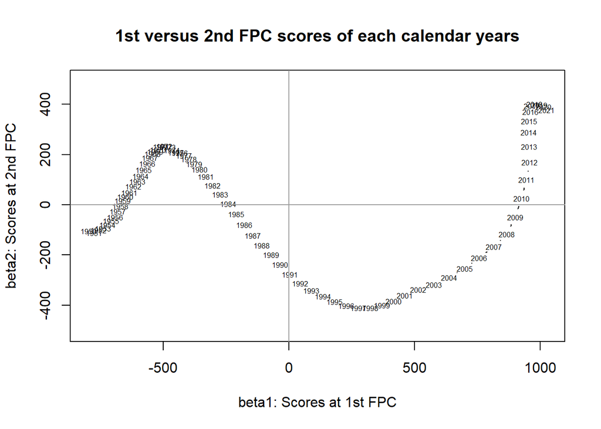

```r
plot(ppDemog.fit$coeff[,2],ppDemog.fit$coeff[,3],type="l",as=1,cex=.5,
     main="1st versus 2nd FPC scores of each calendar years",
     xlab="beta1: Scores at 1st FPC", ylab="beta2: Scores at 2nd FPC")
abline(v=0,h=0,col=8)
```

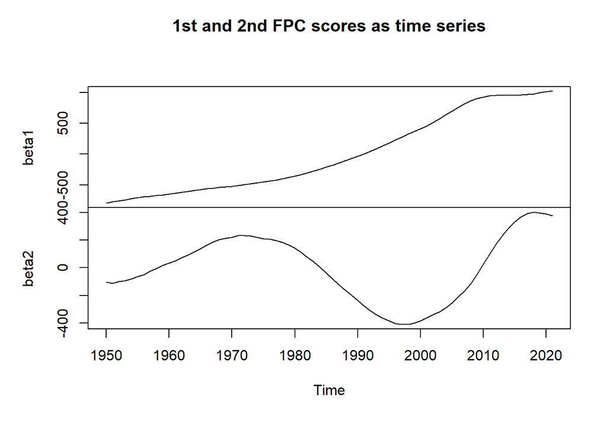

```r
plot(ppDemog.fit$coeff[,2:3], main="1st and 2nd FPC scores as time series")
```

Now, forecasts are computed for a horizon of 20 years:

```r
if (!exists("horiz")) horiz <- 20
ppDemog.fcast <- forecast(ppDemog.fit,h=horiz)
models(ppDemog.fcast)
```

```
##
## -- Coefficient 1 --
## Series: xx[, i]
## ARIMA(1,2,0)
##
## Coefficients:
##          ar1
##       0.5465
## s.e.  0.1001
##
## sigma^2 = 12.19:  log likelihood = -186.46
## AIC=376.93   AICc=377.11   BIC=381.42
##
## -- Coefficient 2 --
## Series: xx[, i]
## ARIMA(1,2,1)
##
## Coefficients:
##          ar1      ma1
##       0.8476  -0.4737
## s.e.  0.1056   0.1696
##
## sigma^2 = 32.6:  log likelihood = -220.51
## AIC=447.03   AICc=447.39   BIC=453.77
```

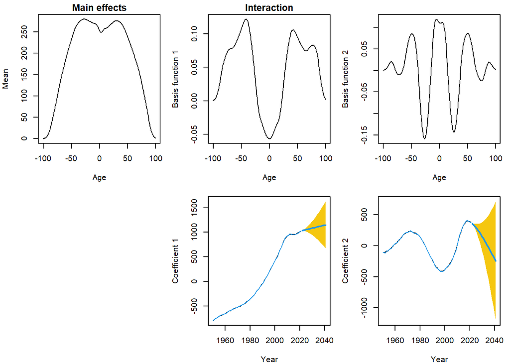

```r
par(mar=c(4,4,1.5,1))
plot(ppDemog.fcast,'c')
```

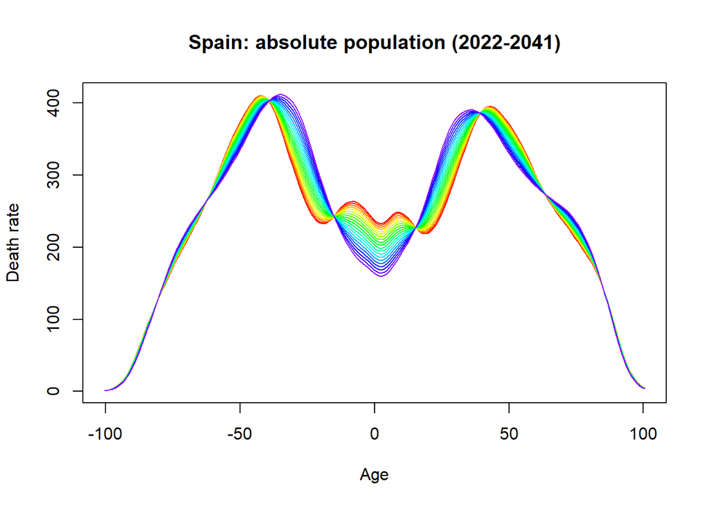

```r
plot(ppDemog.fcast,
     main=paste0(Country[ctr,1],": absolute population (",rev(Year)[1]+1,"-", rev(Year)[1]+horiz,")"))
```

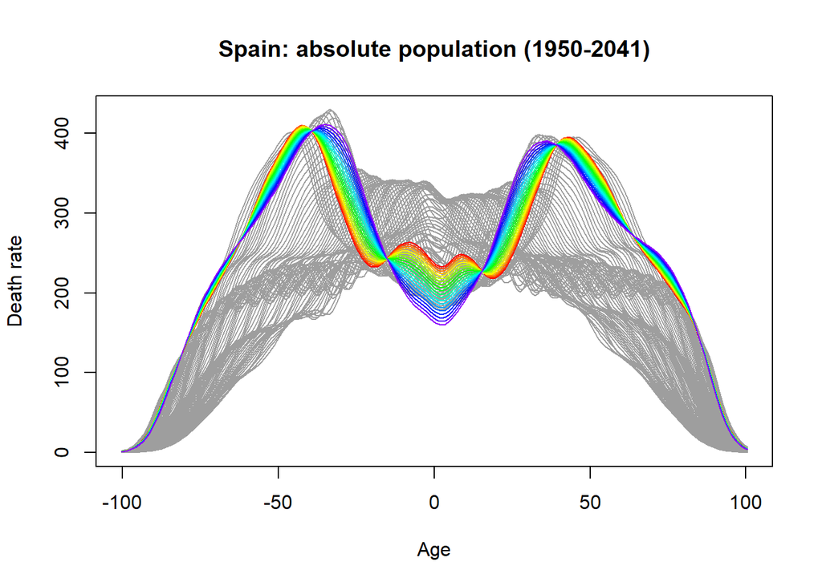

```r
plot(ppDemog, datatype = "rate", col=8,
     main=paste0(Country[ctr,1],": absolute population (",Year[1],"-", rev(Year)[1]+horiz,")"))
plot(ppDemog.fcast,add=TRUE)
```

### 2.3.2 Ploting results as population pyramids

We plot now as population pyramids the modeling and forecasting results.

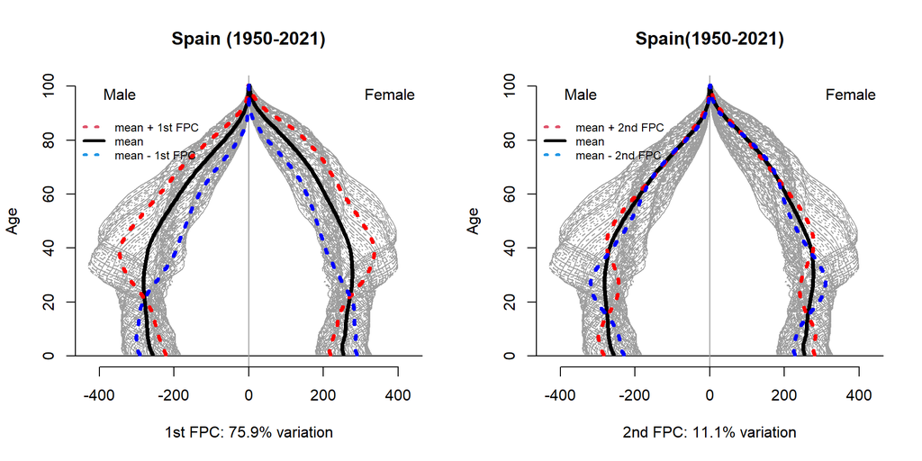

```r
Age.1 <- ppDemog$age[ppDemog$age>0]
par(mfrow=c(1,2))
matplot_pop_pyr_1y(Age.1, t(ppDemog$rate$Total),col=8,
     main=paste0(Country[ctr,1]," (",Year[1],"-", rev(Year)[1],")"))
lines_pop_pyr(Age.1, 1+ppDemog.fit$basis[,1],lwd=4)
eig_val_1 <- var(ppDemog.fit$coeff[,2])
lines_pop_pyr(Age.1, 1+ppDemog.fit$basis[,1]+sqrt(eig_val_1)*ppDemog.fit$basis[,2],lwd=4,col="red",lty=3)
lines_pop_pyr(Age.1, 1+ppDemog.fit$basis[,1]-sqrt(eig_val_1)*ppDemog.fit$basis[,2],lwd=4,col="blue",lty=3)
legend(-470, 90,c("mean + 1st FPC ", "mean", "mean - 1st FPC "),
       lty=c(3,1,3), col=c(2,1,4), lwd=3, bty="n",seg.len = 2, cex=.75)
title(xlab=paste0("1st FPC: ",round(100*ppDemog.fit$varprop[1],1),"% variation"), bty="n")

matplot_pop_pyr_1y(Age.1, t(ppDemog$rate$Total),col=8,
     main=paste0(Country[ctr,1],"(",Year[1],"-", rev(Year)[1],")"))
lines_pop_pyr(Age.1, 1+ppDemog.fit$basis[,1],lwd=4)
eig_val_2 <- var(ppDemog.fit$coeff[,3])
cte=1
lines_pop_pyr(Age.1, 1+ppDemog.fit$basis[,1]+cte*sqrt(eig_val_2)*ppDemog.fit$basis[,3],lwd=4,col="red",lty=3)
lines_pop_pyr(Age.1, 1+ppDemog.fit$basis[,1]-cte*sqrt(eig_val_2)*ppDemog.fit$basis[,3],lwd=4,col="blue",lty=3)
legend(-470, 90,c("mean + 2nd FPC ", "mean", "mean - 2nd FPC "),
       lty=c(3,1,3), col=c(2,1,4), lwd=3, bty="n",seg.len = 2, cex=.75)

title(xlab=paste0("2nd FPC: ",round(100*ppDemog.fit$varprop[2],1),"% variation"), bty="n")
```

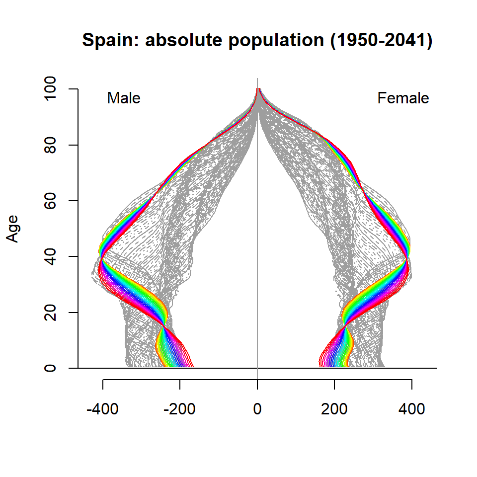

```r
matplot_pop_pyr_1y(Age.1,t(ppDemog$rate$Total), datatype = "rate", col=8,
     main=paste0(Country[ctr,1],
                 ": absolute population (",Year[1],"-", rev(Year)[1]+horiz,")"))
col <- rainbow(horiz, start=0, end=1)
for (i in (1:horiz)){
  lines_pop_pyr(Age.1,ppDemog.fcast$rate$total[,i], col=col[i%%length(col)+1])
}
```

## 2.4 Spain, relative population pyramids

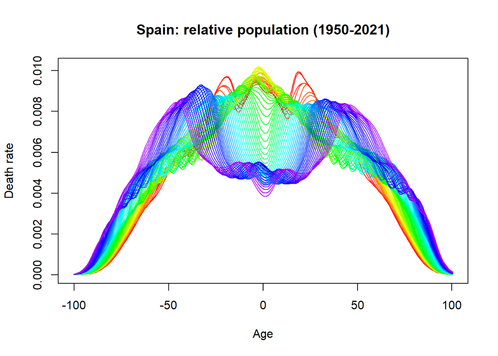

```r
ctr <- 'ES'
ppDemog <- demogdata(data=t(PopPyrRelSm[ctr,,]),
                     pop=t(PopPyrSm[ctr,,]),
                     ages=egAge.1, years=Year,
                     type= "mortality", label=Country[ctr,1],
                     name="Total", lambda=1)
plot(ppDemog, datatype = "rate", # It is possible to use datatype="pop"
     main=paste0(Country[ctr,1],": relative population (",Year[1],"-", rev(Year)[1],")"))
```

### 2.4.1 Modeling and forecasting popultion pyramids

```r
ppDemog.fit <- fdm(ppDemog, order=2)
ppDemog.fit
```

```
## Functional demographic model
##
## Call: fdm(data = ppDemog, order = 2)
##
## Region: Spain
## Data type: mortality
## Years in fit: 1950 - 2021
## Ages in fit: -100.5 - 100.5
##
## Order: 2
## Percentage variation due to basis functions: 73.8% 14.0%
```

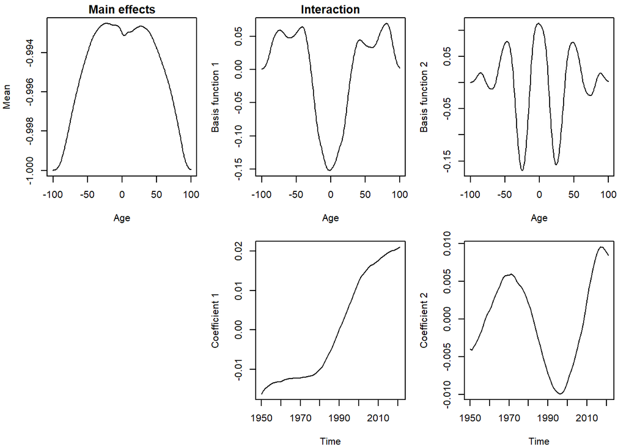

```r
par(mar=c(4,4,1.5,1))
plot(ppDemog.fit)
```

Note in the previous graphics that the **Main effects** are negative in this example. There is no clear reason for this. In fact, here the true estimation of the mean is not the element `basis[,1]` of the fitted model (as in the previous example) but instead it is `1+basis[,1]`.

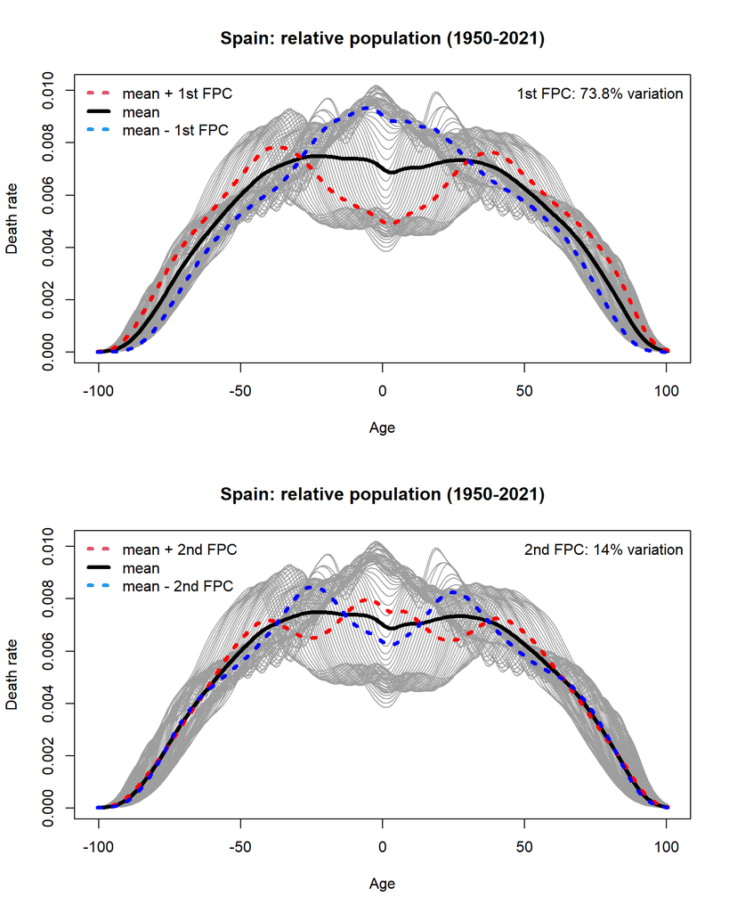

```r
par(mfrow=c(2,1))
plot(ppDemog,col=8,
     main=paste0(Country[ctr,1],": relative population (",Year[1],"-", rev(Year)[1],")"))
lines(ppDemog$age, 1+ppDemog.fit$basis[,1],lwd=4)
eig_val_1 <- var(ppDemog.fit$coeff[,2])
lines(ppDemog$age, 1+ppDemog.fit$basis[,1]+sqrt(eig_val_1)*ppDemog.fit$basis[,2],lwd=4,col="red",lty=3)
lines(ppDemog$age, 1+ppDemog.fit$basis[,1]-sqrt(eig_val_1)*ppDemog.fit$basis[,2],lwd=4,col="blue",lty=3)
legend("topleft",c("mean + 1st FPC ", "mean", "mean - 1st FPC "),
       lty=c(3,1,3), col=c(2,1,4), lwd=4, bty="n",seg.len = 1.5)
legend("topright",paste0("1st FPC: ",round(100*ppDemog.fit$varprop[1],1),"% variation"), bty="n")


plot(ppDemog,col=8,
     main=paste0(Country[ctr,1],": relative population (",Year[1],"-", rev(Year)[1],")"))
lines(ppDemog$age, 1+ppDemog.fit$basis[,1],lwd=4)
eig_val_2 <- var(ppDemog.fit$coeff[,3])
cte=1
lines(ppDemog$age, 1+ppDemog.fit$basis[,1]+cte*sqrt(eig_val_2)*ppDemog.fit$basis[,3],lwd=4,col="red",lty=3)
lines(ppDemog$age, 1+ppDemog.fit$basis[,1]-cte*sqrt(eig_val_2)*ppDemog.fit$basis[,3],lwd=4,col="blue",lty=3)
legend("topleft",c("mean + 2nd FPC ", "mean", "mean - 2nd FPC "),
       lty=c(3,1,3), col=c(2,1,4), lwd=4, bty="n",seg.len = 1.5)
legend("topright",paste0("2nd FPC: ",round(100*ppDemog.fit$varprop[2],1),"% variation"), bty="n")
```

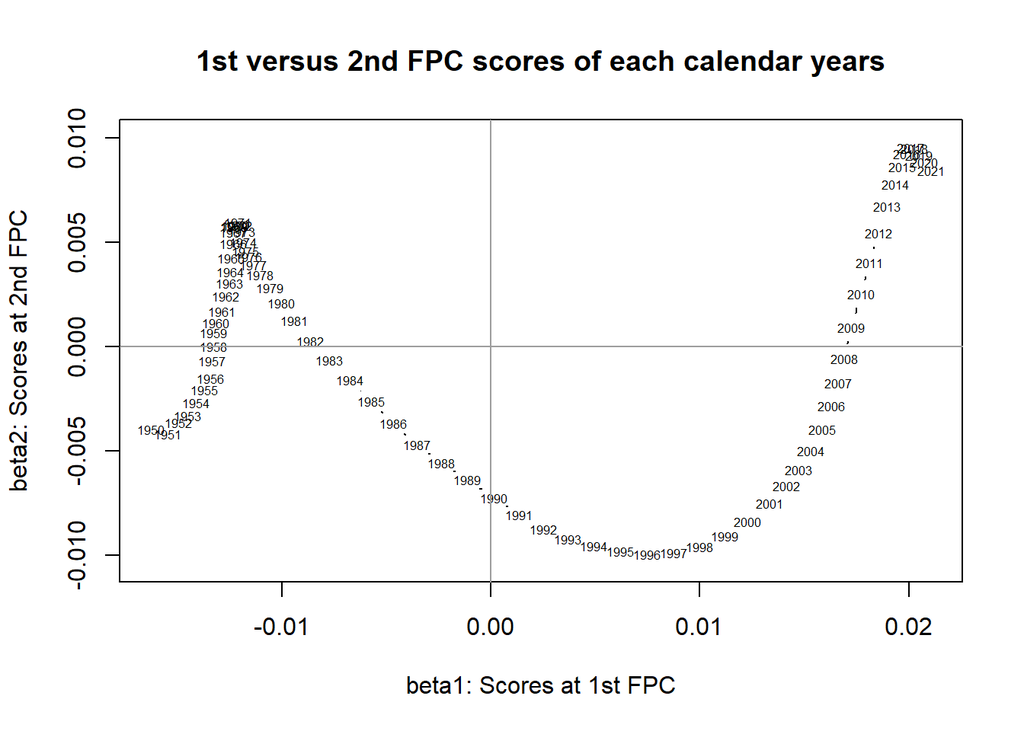

```r
plot(ppDemog.fit$coeff[,2],ppDemog.fit$coeff[,3],type="l",as=1,cex=.5,
     main="1st versus 2nd FPC scores of each calendar years",
     xlab="beta1: Scores at 1st FPC", ylab="beta2: Scores at 2nd FPC")
abline(v=0,h=0,col=8)
```

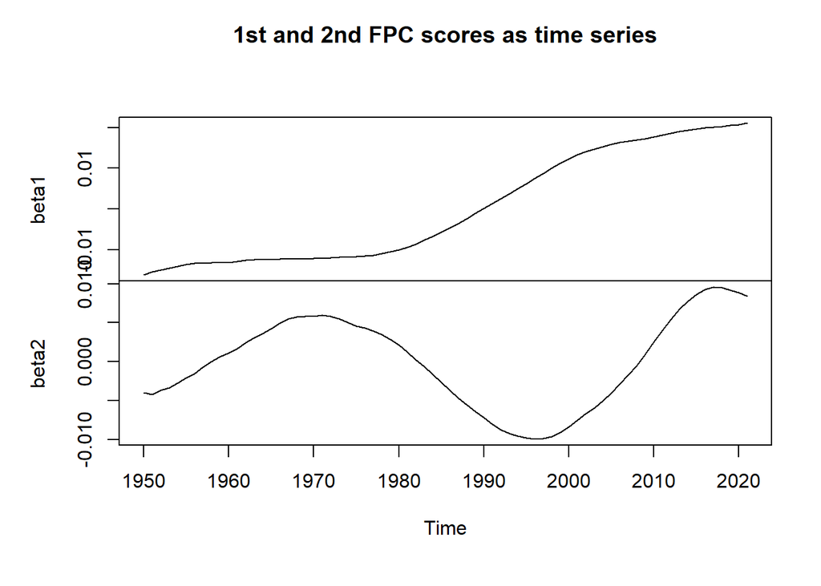

```r
plot(ppDemog.fit$coeff[,2:3], main="1st and 2nd FPC scores as time series")
```

Now, forecasts are computed for a horizon of 20 years:

```r
if (!exists("horiz")) horiz <- 20
ppDemog.fcast <- forecast(ppDemog.fit,h=horiz)
models(ppDemog.fcast)
```

```
##
## -- Coefficient 1 --
## Series: xx[, i]
## ARIMA(1,2,0)
##
## Coefficients:
##          ar1
##       0.4440
## s.e.  0.1163
##
## sigma^2 = 7.234e-09:  log likelihood = 557.17
## AIC=-1110.33   AICc=-1110.15   BIC=-1105.84
##
## -- Coefficient 2 --
## Series: xx[, i]
## ARIMA(3,2,2)
##
## Coefficients:
##           ar1     ar2     ar3     ma1     ma2
##       -0.9771  0.1395  0.5673  1.3941  0.4859
## s.e.   0.1970  0.2363  0.1251  0.2507  0.3079
##
## sigma^2 = 2.557e-08:  log likelihood = 513.81
## AIC=-1015.62   AICc=-1014.29   BIC=-1002.13
```

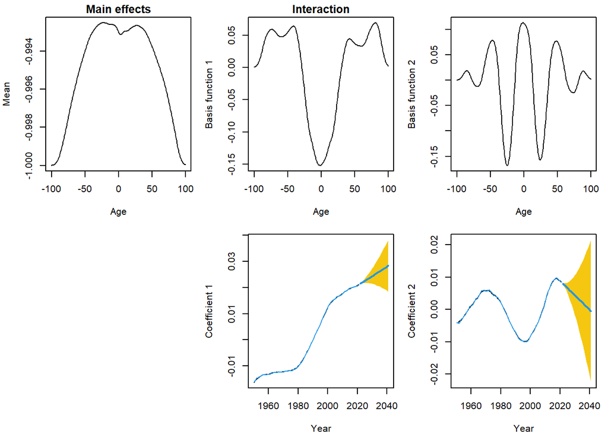

```r
par(mar=c(4,4,1.5,1))
plot(ppDemog.fcast,'c')
```

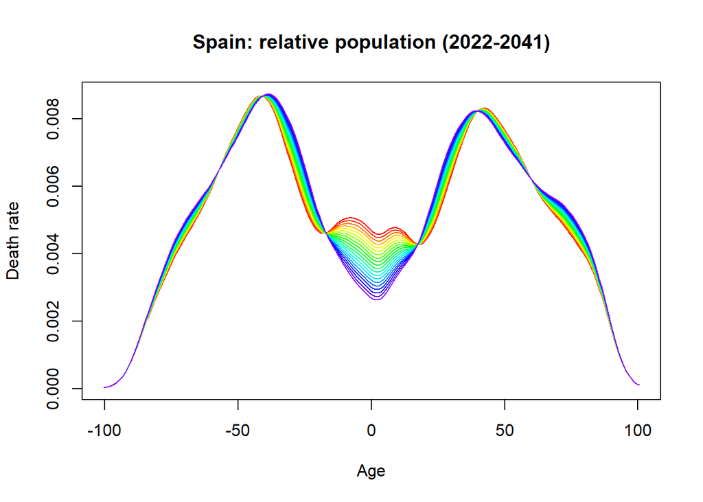

```r
plot(ppDemog.fcast,
     main=paste0(Country[ctr,1],": relative population (",rev(Year)[1]+1,"-", rev(Year)[1]+horiz,")"))
```

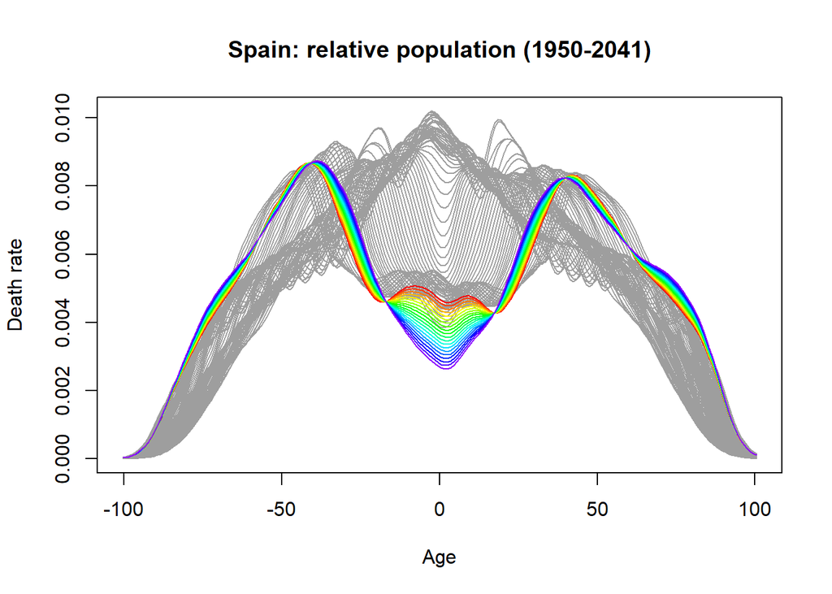

```r
plot(ppDemog, datatype = "rate", col=8,
     main=paste0(Country[ctr,1],": relative population (",Year[1],"-", rev(Year)[1]+horiz,")"))
plot(ppDemog.fcast,add=TRUE)
```

### 2.4.2 Ploting results as population pyramids

We plot now as population pyramids the modeling and forecasting results.

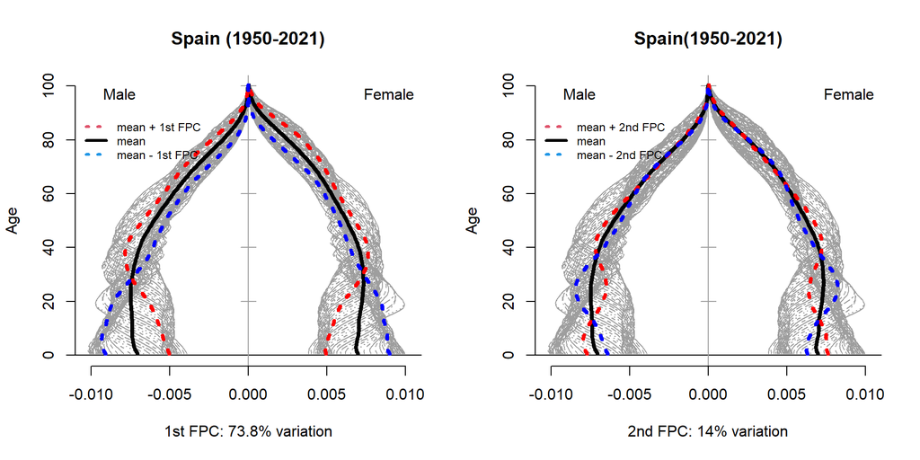

```r
Age.1 <- ppDemog$age[ppDemog$age>0]
par(mfrow=c(1,2))
matplot_pop_pyr_1y(Age.1, t(ppDemog$rate$Total),col=8,
     main=paste0(Country[ctr,1]," (",Year[1],"-", rev(Year)[1],")"))
lines_pop_pyr(Age.1, 1+ppDemog.fit$basis[,1],lwd=4)
eig_val_1 <- var(ppDemog.fit$coeff[,2])
lines_pop_pyr(Age.1, 1+ppDemog.fit$basis[,1]+sqrt(eig_val_1)*ppDemog.fit$basis[,2],lwd=4,col="red",lty=3)
lines_pop_pyr(Age.1, 1+ppDemog.fit$basis[,1]-sqrt(eig_val_1)*ppDemog.fit$basis[,2],lwd=4,col="blue",lty=3)
legend(-.011, 90,c("mean + 1st FPC ", "mean", "mean - 1st FPC "),
       lty=c(3,1,3), col=c(2,1,4), lwd=3, bty="n",seg.len = 2, cex=.75)
title(xlab=paste0("1st FPC: ",round(100*ppDemog.fit$varprop[1],1),"% variation"), bty="n")

matplot_pop_pyr_1y(Age.1, t(ppDemog$rate$Total),col=8,
     main=paste0(Country[ctr,1],"(",Year[1],"-", rev(Year)[1],")"))
lines_pop_pyr(Age.1, 1+ppDemog.fit$basis[,1],lwd=4)
eig_val_2 <- var(ppDemog.fit$coeff[,3])
cte=1
lines_pop_pyr(Age.1, 1+ppDemog.fit$basis[,1]+cte*sqrt(eig_val_2)*ppDemog.fit$basis[,3],lwd=4,col="red",lty=3)
lines_pop_pyr(Age.1, 1+ppDemog.fit$basis[,1]-cte*sqrt(eig_val_2)*ppDemog.fit$basis[,3],lwd=4,col="blue",lty=3)
legend(-.011, 90,c("mean + 2nd FPC ", "mean", "mean - 2nd FPC "),
       lty=c(3,1,3), col=c(2,1,4), lwd=3, bty="n",seg.len = 2, cex=.75)

title(xlab=paste0("2nd FPC: ",round(100*ppDemog.fit$varprop[2],1),"% variation"), bty="n")
```

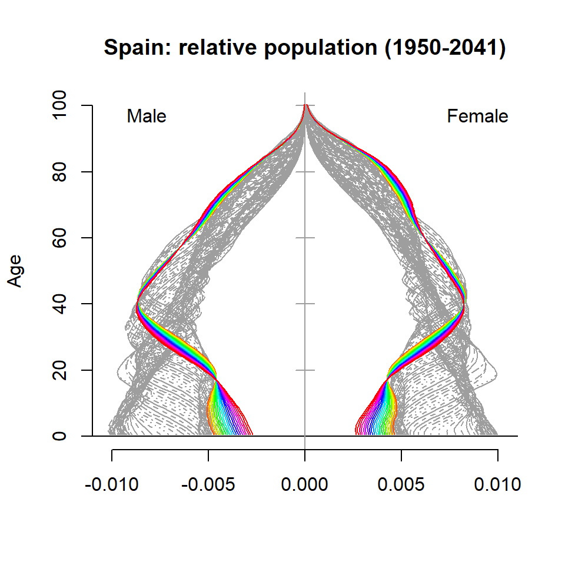

```r
matplot_pop_pyr_1y(Age.1,t(ppDemog$rate$Total), datatype = "rate", col=8,
     main=paste0(Country[ctr,1],
                 ": relative population (",Year[1],"-", rev(Year)[1]+horiz,")"))
col <- rainbow(horiz, start=0, end=1)
for (i in (1:horiz)){
  lines_pop_pyr(Age.1,ppDemog.fcast$rate$total[,i], col=col[i%%length(col)+1])
}
```